# Chicago City Council: local ideal points, 2023–2026

Pooled roll calls, 2023–2026 · Preliminary analysis

Author

Boris Shor

Updated

October 8, 2026

This pilot uses contested roll calls from 2023 through 2026 to place **52 Chicago City Council members** on a common voting spectrum. The pattern runs from DSA and progressive members to a more moderate or conservative Democratic bloc, and it broadly tracks the political character of members’ wards in the 2024 presidential election. The sample contains no contemporary Republicans: the important divisions are within Chicago’s overwhelmingly Democratic political world.

**52 members**  
Pooled across service changes

**50 wards**  
One elected council

**189 roll calls**  
Contested council decisions

**9,133 votes**  
Recorded yeas and nays

## Dataset

The roll calls come from the *MyTown* corpus of local-government meetings and votes (Jacob Greene, 2026, CC BY 4.0, [DOI 10.57967/hf/9676](https://doi.org/10.57967/hf/9676)), downloaded September 14, 2026. Preserved local extracts, rather than later downloads, define this analysis.

### Coverage and construction

The pooled sample includes **52 distinct council members across 50 wards**, observed at **58 meetings** from June 2023 through July 2026. The source contains 689,152 individual member-vote records across 13,783 meeting–motion items. Only 189 items contain both yea and nay votes; **all 189 enter the main ideal-point fit**, including 58 with a one-member minority. They contain 9,133 observed yea/nay votes.

| Measure | Value |
| --- | --- |
| Council member-vote rows | 689,152 |
| Council meetings | 58 |
| Coverage | June 21, 2023–July 15, 2026 |
| Distinct meeting × motion items | 13,783 |
| Items with yea and nay | 189 |
| Distinct council members | 52 |
| Roll calls retained for the fit | 189 |
| Recorded yeas and nays in the fit | 9,133 |

The analysis covers the elected City Council and pools each member’s recorded votes over their service. Absences, abstentions and unrecorded responses are not treated as nays. Most council business is unanimous, so only a small share of the recorded motions distinguishes members’ voting positions.

The analysis excludes council members with fewer than four usable yea/nay votes and unanimous motions. All 52 members have sufficient voting records. A single dissenter is enough to retain a contested motion: in a fifty-seat council these votes help identify members willing to stand apart, rather than treating their disagreement as uninformative.

One source check compared all 50 member votes on budget ordinance SO2024-0014393 with Chicago’s official API: all matched, with 27 yeas and 23 nays. This verifies one item, not the full corpus. [Official matter and votes](https://api.chicityclerkelms.chicago.gov/matter/15835B27-15B7-EF11-B8E9-001DD8306DF0)

## Council voting positions

An **ideal point** is a one-dimensional summary of how similarly council members vote on contested roll calls. Members placed near one another tend to vote alike; members far apart tend to take opposing sides. Its direction and units are relative to this Chicago sample, so it should be read as a voting-position scale—not as a direct measure of party identity or an absolute liberal–conservative score.

The estimates pool years and come from a Bayesian roll-call model.

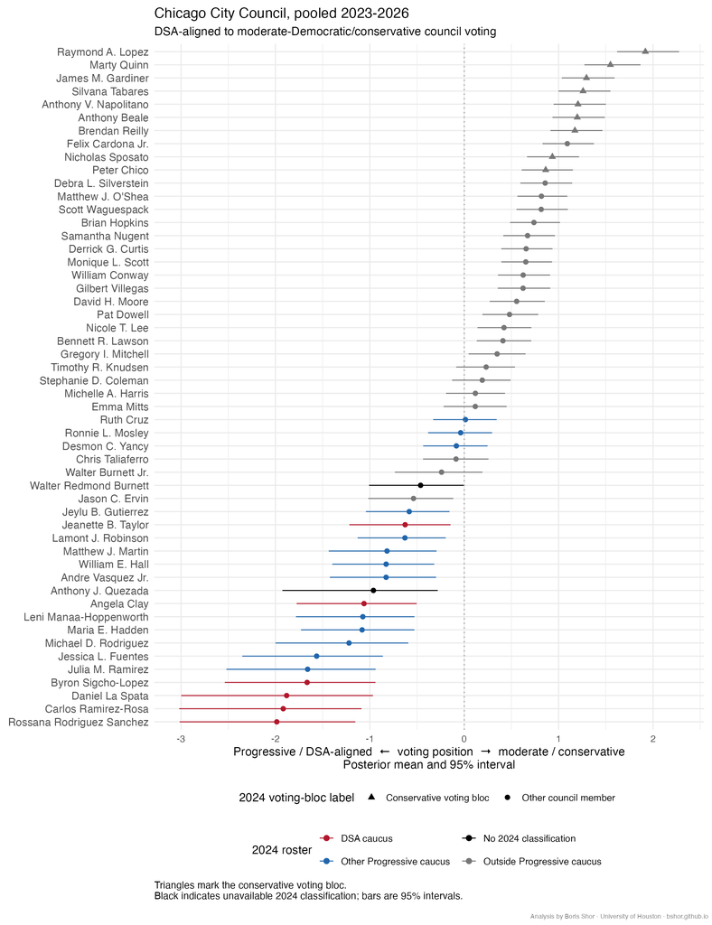

Pooled voting positions and 95% posterior intervals. Colors distinguish the 2024 DSA and Progressive rosters; triangles identify the conservative voting bloc. Black indicates unavailable 2024 classification.

## Presidential voting by ward

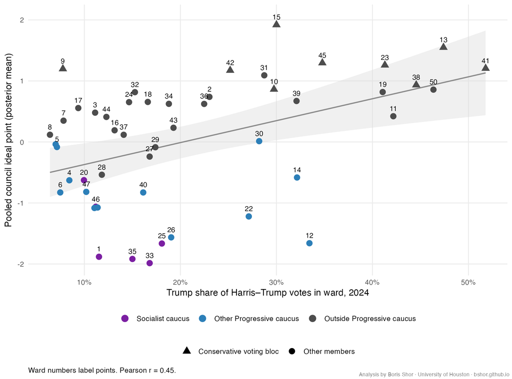

Ward presidential voting and the pooled council ideal point. Points are the alderpeople serving on November 5, 2024; ward numbers label observations.

The analysis aggregates the *New York Times* published 2024 presidential precinct results to Chicago’s 50 wards and matches each ward to the alderperson serving on Election Day. It uses Trump’s share of the two-party Harris–Trump vote rather than the Republican share of all ballots. The two later successors present in the pooled roll-call data are excluded from this date-specific match. The underlying file contains all 1,291 Chicago precinct rows. Its citywide Harris and Trump counts cover 99.97% of the certified two-candidate total; the small difference from the official canvass is disclosed rather than adjusted across wards. [*New York Times* precinct-data documentation](https://github.com/nytimes/presidential-precinct-map-2024); [Chicago Board of Election Commissioners certified canvass](https://cboeprod.blob.core.usgovcloudapi.net/prod/2024-11/Proclamation%20of%20Official%20Results%20%28November%205%2C%202024%29.pdf)

The relationship has the expected sign and moderate magnitude: Pearson’s correlation is **0.45** across 50 wards. In a simple bivariate regression, a 10-percentage-point increase in Trump’s two-party ward share corresponds to **0.36 ideal-point units** (R² = 0.20). This is a useful external face-validity check because presidential votes did not enter the ideal-point model.

It is not a party-sorting test or a causal model. Chicago council elections are officially nonpartisan; ward presidential voting measures constituents, whereas the ideal point measures an officeholder’s behavior on the selected council roll calls. The considerable dispersion around the fitted line is substantively important. For example, Progressive Julia Ramirez in Ward 12 has a low council ideal point despite a comparatively high Trump share, while Anthony Beale in Ward 9 has a positive council score despite a comparatively low Trump share. Council coalitions, candidate-specific politics, ward composition, and the limited set of contested roll calls can all produce such mismatches.

## Members and policy controversies

**Raymond Lopez** occupies the positive endpoint, just ahead of Quinn, while **Daniel La Spata** sits near the progressive end. Positions summarize how members vote across the council’s contested decisions, not just their own no-vote totals.

The news record supports reading the recovered dimension as a spectrum from **DSA-aligned voting** to a **moderate-Democratic/conservative council bloc**, rather than as a conventional Democrat–Republican scale.

At the positive end, Marty Quinn (posterior mean 1.55) is generally described as a moderate Democrat and a reliable member of the council coalition challenging Mayor Brandon Johnson. During the period covered here, he opposed **Bring Chicago Home**, a proposed graduated real-estate transfer tax that would have cut the rate on sales below $1 million, raised it on more expensive properties, and dedicated the proceeds to homelessness programs. The controversy concerned both redistribution and implementation: supporters projected roughly $100 million annually for housing and services, while opponents disputed the revenue assumptions, warned about effects on real-estate activity, and questioned how the money would be administered. Quinn also pressed to retain **ShotSpotter**, the acoustic gunshot-detection system whose city contract Johnson ended. Supporters argued that its alerts speed police and emergency response; critics emphasized cost, alerts that did not yield evidence of gun crime, associated police deployments, and the absence of demonstrated public-safety gains. Chicago’s inspector general found that most deployments prompted by alerts in its study period did not produce evidence of a gun-related crime and cautioned that the available data could not establish whether ShotSpotter was effective. [WBEZ on Bring Chicago Home](https://www.wbez.org/politics/2024/03/18/what-the-bring-chicago-home-referendum-would-do); [*Chicago Sun-Times* on Quinn, ShotSpotter, and the Johnson budget](https://chicago.suntimes.com/city-hall/2024/10/17/mayor-johnson-city-budget-city-council-shotspotter-property-taxes-armory-marty-quinn); [Chicago inspector general’s ShotSpotter analysis](https://igchicago.org/wp-content/uploads/2023/08/Chicago-Police-Departments-Use-of-ShotSpotter-Technology.pdf)

Raymond Lopez (1.92) has been described more directly as one of the council’s more conservative members. He helped pursue a **sanctuary-city referendum** that would have asked voters whether Chicago should retain its Welcoming City protections amid conflict over the public cost of sheltering newly arrived migrants. Its advocates framed this as voter control over spending and immigration policy; opponents argued that the proposal targeted migrants and put longstanding protections limiting city cooperation with federal immigration enforcement at risk. [WBEZ profile of Lopez](https://www.wbez.org/politics/2022/04/06/chicago-mayor-candidate-ald-raymond-lopez); [Axios on the sanctuary-city dispute](https://www.axios.com/local/chicago/2023/11/02/sanctuary-city-referendum-vote-delayed)

At the negative end, Rossana Rodríguez-Sánchez (-1.99) and Carlos Ramirez-Rosa (-1.92) are prominent DSA members. Rodríguez-Sánchez led **Treatment Not Trauma**, which seeks expanded city-run mental-health clinics and a non-police response to behavioral-health crises. Debate has focused on the cost and pace of reopening public clinics, whether city employees or nonprofit providers should deliver care, and when police should remain part of crisis response. [WTTW questionnaire for Rodríguez-Sánchez](https://news.wttw.com/elections/voters-guide/2023/Rossana-Rodriguez-Sanchez); [WBEZ on Treatment Not Trauma](https://www.wbez.org/politics/2023/07/25/mayoral-allies-lay-groundwork-for-treatment-not-trauma-mental-health-plan); [WBEZ on clinic costs and provision](https://www.wbez.org/politics/2023/05/11/johnson-assessing-mental-health-needs-before-reopening-clinics)

Ramirez-Rosa chaired the council’s DSA caucus and advocated **municipalizing ComEd**—having the city acquire the investor-owned electric distribution system and operate a public utility. Supporters presented public ownership as a route to democratic accountability, cleaner energy, and lower costs; critics pointed to the potentially enormous acquisition price, debt burden, legal fight, and operational risk of replacing an established utility. [WBEZ on council progressives](https://www.wbez.org/politics/2023/01/10/chicago-progressives-seeking-more-city-council-seats); [WTTW on municipalizing ComEd](https://news.wttw.com/2019/07/03/socialized-electricity-alderman-floats-government-takeover-comed)

The intervals overlap substantially within each pair, so the small differences between Quinn and Lopez, or between Rodríguez-Sánchez and Ramirez-Rosa, should not be interpreted as reliable individual rankings. The news evidence instead validates the broader separation between recognizable council blocs.

## Caucuses and endorsements

The following memberships come from the dated rosters in Tables 5–10 of the UIC [first-year Johnson report](https://pols.uic.edu/wp-content/uploads/sites/273/2024/06/Mayor-Brandon-Johnsons-First-Year.pdf). They are snapshots, not claimed continuous memberships. Members not covered by the 2024 roster are left unclassified. Membership in demographic caucuses is an organizational fact, not an inferred demographic identity. A separate DSA category uses Chicago DSA’s 2027 election endorsements announced in August 2026; it records campaign support, not membership in the council’s DSA caucus.

The conservative voting bloc is shown with triangles in the plot. All nine members of that bloc are outside both the Progressive and DSA caucuses in the same 2024 snapshot.

**Caucus rosters**

| Group | Listed members | Not listed | Median: listed | Median: not listed |
| --- | --- | --- | --- | --- |
| DSA caucus | 6 | 44 | -1.77 | 0.42 |
| Progressive Reform caucus | 19 | 31 | -1.06 | 0.66 |
| Conservative voting bloc | 9 | 41 | 1.21 | -0.04 |
| Black caucus | 19 | 31 | -0.04 | 0.62 |
| Latino caucus | 14 | 36 | -1.02 | 0.42 |
| LGBT caucus | 9 | 41 | -1.07 | 0.42 |

Each row compares people listed in that group’s 2024 roster with people not listed in that particular roster. These comparisons use 50 classified council members; the two later successors lack a 2024 classification. Because the categories overlap, “not listed” does not mean outside every caucus.

The DSA and Progressive Reform groups lie toward the negative end, while the conservative voting bloc lies toward the positive end. Black Caucus membership shows little separation on this particular voting dimension.

These are descriptive comparisons based on a 2024 snapshot, not proof that the memberships remained unchanged throughout 2023–2026. The conservative bloc is itself a voting-based classification by the UIC report’s authors, so its close match with the roll-call scale is suggestive but not independent validation.

**Within the Progressive caucus**

| Group | Council members (N) | Median voting position |
| --- | --- | --- |
| DSA caucus | 6 | -1.77 |
| Other Progressive caucus | 13 | -0.83 |

This comparison is restricted to the 19 Progressive caucus members: six DSA caucus members and 13 other Progressives. The DSA members sit further toward the negative end, although neither subgroup is uniform. The caucus’s [own historical roster](https://chicagosocialistcaucus.org/who-we-are) provides an additional organizational source. No outside-Progressive members enter this comparison.

**DSA endorsements**

Chicago DSA’s [2027 endorsement announcement](https://chicagodsa.org/2026/08/15/announcing-chicago-dsas-2027-endorsements/) names four people in this pooled sample: Angela Clay, Anthony Quezada, Rossana Rodríguez-Sánchez and Byron Sigcho-Lopez. Endorsement is distinct from belonging to the 2024 officeholder caucus, and the dates differ. The announcement is a later external comparison, not a membership classification for every earlier vote.

| Group | Members | Median voting position |
| --- | --- | --- |
| Named in 2027 endorsement announcement | 4 | -1.36 |
| Other pooled members | 48 | 0.29 |

“Other pooled members” means not named in this announcement, not never endorsed by DSA. These are descriptive comparisons of estimated voting positions, not causal effects.

## Party affiliations: are there Republicans?

**The evidence points to no Republican-affiliated members in this Chicago sample under contemporary public-affiliation coding.** This is a research conclusion from external sources, not a count provided by MyTown, and it is not a claim that the members lack conservative views.

The two cases most easily mistaken for Republicans are **Anthony Napolitano and Nicholas Sposato**. Sposato explicitly supplied “Independent” as his party in his 2023 candidate questionnaire. Napolitano described himself as independent in his own 2019 statement, and contemporaneous 2023 reporting also classifies him as independent. Jim Gardiner, another member toward the positive end, explicitly supplied “Democrat” in his 2023 questionnaire. [Sposato, 2023](https://news.wttw.com/elections/voters-guide/2023/Nicholas-Sposato); [Napolitano’s statement](https://news.wttw.com/elections/voters-guide/2019/candidates/chicago-city-council/anthony-napolitano); [2023 reporting](https://www.thedailyline.com/2023-chicago-racing-form); [Gardiner, 2023](https://news.wttw.com/elections/voters-guide/2023-runoff/jim-gardiner)

UIC’s study of the preceding council describes Sposato and Napolitano as independents and discusses Napolitano’s earlier Republican affiliation. Historical Republican ties should therefore not be silently treated as a Republican label throughout 2023–2026. [UIC, *Lori Lightfoot’s Mayoralty*, p. 3](https://pols.uic.edu/wp-content/uploads/sites/273/2023/09/Lori-Lightfoots-Mayoralty.pdf)

As a broad cross-check, the current secondary council roster lists 48 Democrats and two independents, not a Republican bloc. That is a current 50-seat snapshot—not a primary-source census of the 52 distinct people in our pooled data. Its two independents are Sposato and Napolitano. [Council roster](https://en.wikipedia.org/wiki/Chicago_City_Council)

Our **strict individual evidence file** deliberately remains more conservative: 29 people have documented Democratic party offices, Gardiner has a Democratic self-description, two have independent self-descriptions, and the rest retain an unverified label. An unverified member is not coded Republican. The party-office source includes members at both estimated extremes. [Cook County Democratic Party directory](https://www.cookcountydems.com/committeepersons/)

| Evidence category (dates differ) | People |
| --- | --- |
| Democratic party office documented | 29 |
| Democratic self-description (2023) | 1 |
| Independent self-description (2019); historical GOP ties | 1 |
| Independent self-description (2023) | 1 |
| Unverified | 20 |

Consequently, a Democrat–Republican separation test is not informative here. **Organizational caucus memberships offer a better face-validity comparison**, while still requiring dates and acknowledging that ideology, party, and mayoral alignment are different constructs.

## Interpretation and limits

Chicago’s contested votes distinguish a progressive–moderate divide within a largely Democratic council, supported by caucus memberships and ward presidential results. These are city-specific voting positions; detailed estimation and construction limits are in the technical appendix.